# First T-FLASH Fit of GTEX Data

### Next 5 Factors

There seems to be more observable associations between subject phenotypes and subject components in the next five factors.

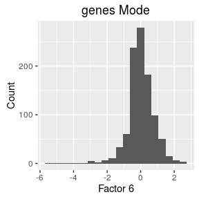

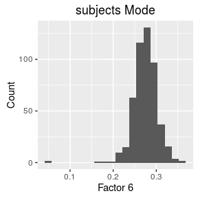

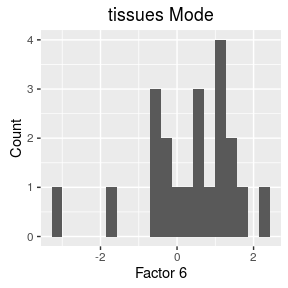

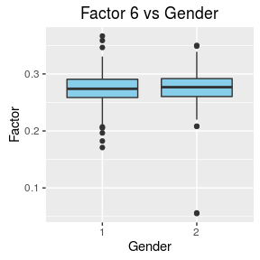

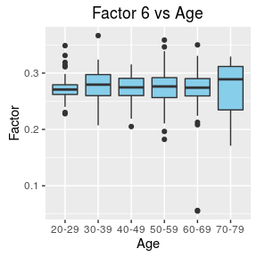

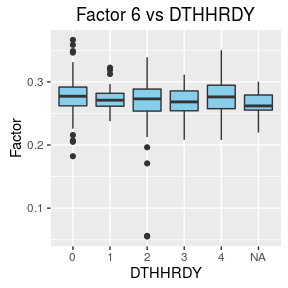

| Tissue | Factor |
| --- | --- |
| Skin | -3.3 |
| Salivary Gland | -1.7 |
| Nerve | -0.6 |
| Esophagus | -0.5 |
| Breast | -0.5 |
| Muscle | -0.3 |
| Blood | -0.3 |
| Adipose Tissue | -0.0 |
| Pituitary | 0.2 |
| Thyroid | 0.5 |
| Blood Vessel | 0.5 |
| Colon | 0.6 |
| Kidney | 0.9 |
| Adrenal Gland | 1.0 |
| Small Intestine | 1.1 |
| Lung | 1.2 |
| Stomach | 1.3 |
| Spleen | 1.4 |
| Pancreas | 1.5 |
| Liver | 1.8 |
| Heart | 2.1 |

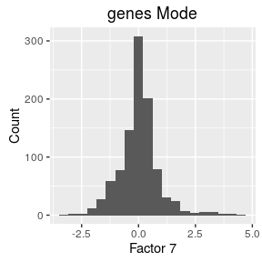

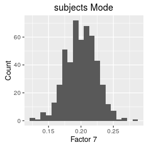

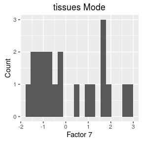

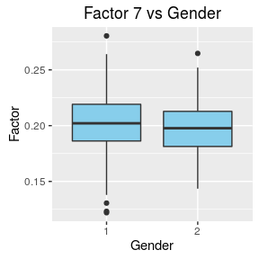

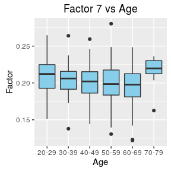

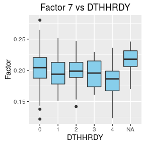

| Tissue | Factor |
| --- | --- |
| Adipose Tissue | -1.8 |
| Blood Vessel | -1.5 |
| Nerve | -1.5 |
| Colon | -1.2 |
| Small Intestine | -1.1 |
| Pancreas | -1.0 |
| Breast | -1.0 |
| Muscle | -0.8 |
| Spleen | -0.7 |
| Blood | -0.5 |
| Esophagus | -0.4 |
| Stomach | -0.2 |
| Liver | 0.5 |
| Salivary Gland | 0.9 |
| Adrenal Gland | 1.2 |
| Kidney | 1.6 |
| Skin | 1.6 |
| Lung | 1.7 |
| Pituitary | 1.9 |
| Heart | 2.6 |
| Thyroid | 2.8 |

[18 more figures not shown]

| Tissue | Factor |
| --- | --- |
| Small Intestine | -3.4 |
| Colon | -2.7 |
| Pituitary | -2.1 |
| Stomach | -1.6 |
| Adrenal Gland | -1.2 |
| Salivary Gland | -1.2 |
| Kidney | -0.9 |
| Esophagus | -0.8 |
| Thyroid | -0.5 |
| Muscle | -0.4 |
| Spleen | -0.3 |
| Liver | -0.0 |
| Blood | 0.3 |
| Nerve | 0.4 |
| Skin | 0.4 |
| Breast | 0.6 |
| Blood Vessel | 0.7 |
| Heart | 1.1 |
| Lung | 1.1 |
| Adipose Tissue | 1.2 |
| Pancreas | 2.5 |

```r
for(kindex in 6:10) {
  for(mode_index in 1:3) {
      print(qplot(tout$factor_list[[mode_index]][, kindex], xlab = paste0("Factor ", kindex),
             ylab = "Count", main = paste(names(dimnames(gtex_array))[mode_index], "Mode"),
              bins = 20))
  }
  plot_pheno(tout$factor_list, subject_pheno, kindex)
  factor_order <- order(tout$factor_list[[3]][, kindex])
  print(xtable(data.frame(Tissue = dimnames(gtex_array)$tissues[factor_order],
                          Factor = tout$factor_list[[3]][, kindex][factor_order]),
               digits = 1),
        include.rownames = FALSE, type = "html")
}
```

## Some pairs plots with absolute coorelations in top right.

I don’t really see much out of the pairs plots.

```r
panel.cor <- function(x, y, digits = 2, prefix = "", cex.cor, ...)
{
    usr <- par("usr"); on.exit(par(usr))
    par(usr = c(0, 1, 0, 1))
    r <- abs(cor(x, y))
    txt <- format(c(r, 0.123456789), digits = digits)[1]
    txt <- paste0(prefix, txt)
    if(missing(cex.cor)) cex.cor <- 0.8/strwidth(txt)
    text(0.5, 0.5, txt, cex = cex.cor * r)
}
```

First The genes components.

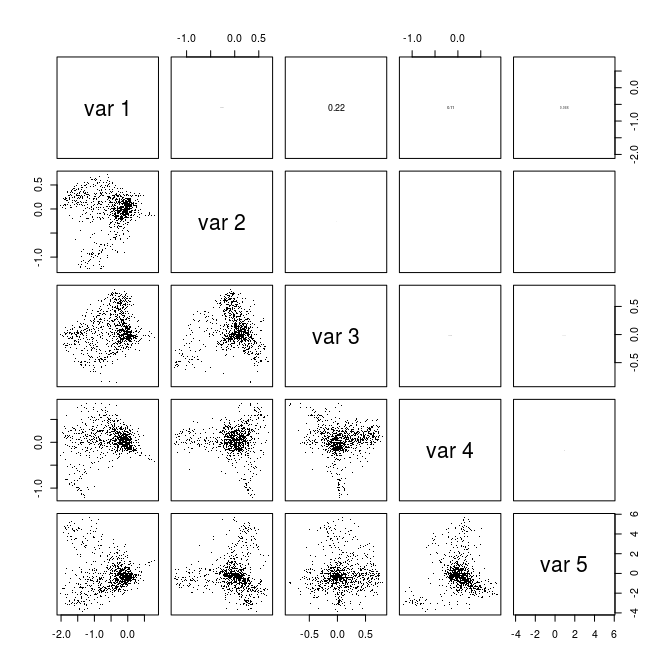

```r
pairs(tout$factor_list[[1]][, 1:5], upper.panel = panel.cor, pch = ".")
```

Now the samples components. I color coded the samples factors by gender.

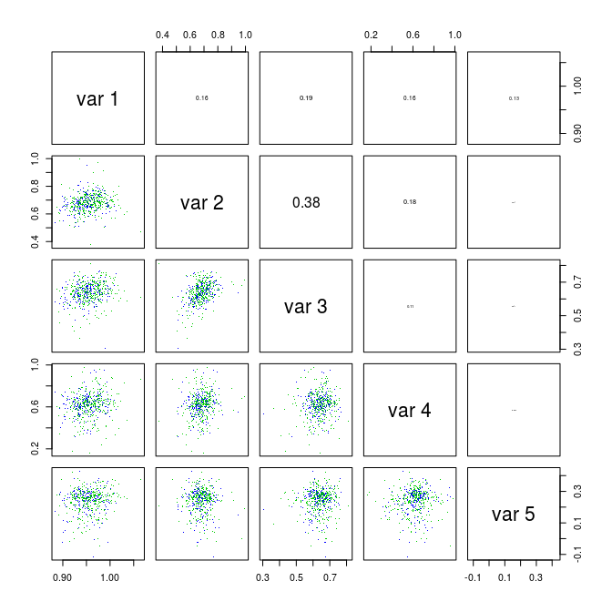

```r
pairs(tout$factor_list[[2]][, 1:5], upper.panel = panel.cor, pch = ".",
      col = subject_pheno$GENDER + 2)
```

Now the tissues components.

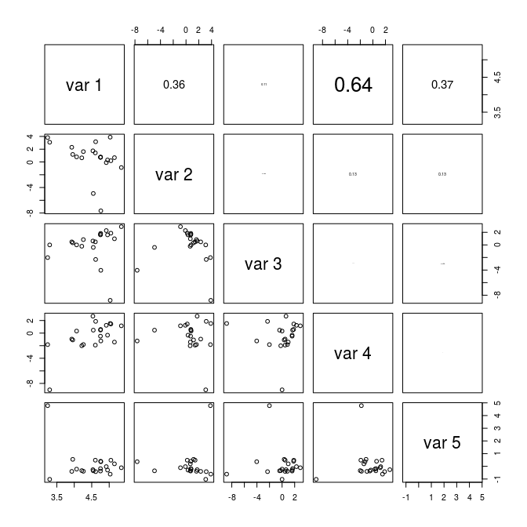

```r
pairs(tout$factor_list[[3]][, 1:5], upper.panel = panel.cor)
```

## General Comments

I’m not too sure the subjects mode is super important. Mostly, it’s just loading moderately positively. I only start seeing patterns at the fifth factor. It might make more sense to treat subjects as independent replications. For example
$$Y_i \overset{ind}{\sim} N_{p \times n}(F L^T, \sigma^2 I_p \otimes I_n).$$

We could also include a regression term for age and overall mean. For example
$$E[Y_{it}] = FL^T + (\alpha_i + \mu)11^T,$$
where $\alpha_i$ is the main effect for age group $i$ ($t$ indexes a replicate here), $\mu$ is the overall mean, and $1$ is the vector of ones. This is different from the current model:
$$E[Y_i] = F C_i L^T,$$
where $C_i$ is a diagonal matrix with the samples factors.